# Embedding R Markdown Within an R Script

### The same plot, resized and centered.

It’s possible to manipulate figure placement properties in the chunk options by setting `fig.width` and `fig.height`.

When writing a LaTeX PDF, setting the `fig.cap` option automatically generates a numbered figure caption!

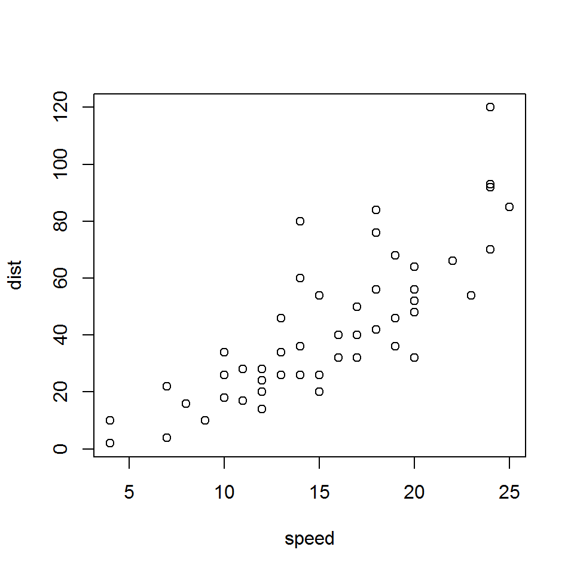

```r
plot(dist~speed,data=cars)
```

### The same plot, but with code only.

Setting `eval=F` in chunk options allows us to exclude output.

```r
plot(dist~speed,data=cars)
```

### Evaluating R code in background

Notice that in the plot below we are referencing a *new field* we have added to ‘cars’ called ‘dist_m’. The variable is being calculated within the script and masked using the `include=F` chunk option.

This is especially handy for keeping functions embedded in your R script hidden. It can also be used to import libraries and source other R scripts discretely.

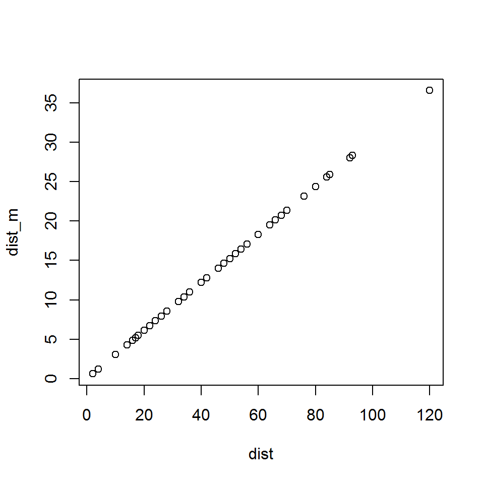

```r
plot(dist_m~dist,data=cars)
```

### Embedding code from other languages in the notebook

Setting the `engine` chunk option allows us to evaluate code in the notebook from a number of languages besides R.

Here’s an example using some Python code (might come in handy sometime if you like working between R and Python).

```python
print ["Jan "+str(i) for i in range(1,20)]
```

```
## ['Jan 1', 'Jan 2', 'Jan 3', 'Jan 4', 'Jan 5', 'Jan 6', 'Jan 7', 'Jan 8', 'Jan 9', 'Jan 10', 'Jan 11', 'Jan 12', 'Jan 13', 'Jan 14', 'Jan 15', 'Jan 16', 'Jan 17', 'Jan 18', 'Jan 19']
```